# Rapport de Projet : Classification bayésienne et analyse factorielle discriminante

## 1 Introduction

Le jeu de données contient des informations sur les **thèses de doctorat françaises**, en mettant l’accent sur la similarité sémantique. Cela représente un défi unique pour la classification en raison de la nature textuelle et sémantique des données.  
L’objectif est de mettre en place une **classification bayésienne avancée avec analyse discriminante** sur ce jeu de données de résumés de thèses de doctorat françaises afin de les catégoriser en **domaines d’étude.**

On divise alors ce projet en **3 grandes étapes :** La création du modèle de données, la modélisation via l’apprentissage supervisé et enfin les différentes visualisations et conclusions soutirées.

## 2 Chargement et pré-traitement des données

**La première partie consiste en la préparation des données.**

### 2.1 Les librairies

Tout d’abord, on vient définir les librairies qui vont être utilisés dans l’ensemble du code. Chaque package a un rôle spécifique pour transformer du texte brut en données mathématiques et générer nos visualisations :

- **tidyverse :** La base pour manipuler les données. Il regroupe plusieurs outils, notamment *dplyr*, qui permet de filtrer, sélectonner et transformer efficacement les variables du jeu de données.
- **tm :** Vient construire le corpus textuel, afin d’appliquer des opérations de nettoyage et de créer une matrice document-terme.
- **SnowballC :** Utilisé pour le stemming, pour ramener les mots à leur racine grammaticale.
- **MASS :** Contient la fonction *lda()*, c’est le moteur de l’AFD.
- **caret, e1071 :** Permettent de réaliser l’apprentissage automatique (Bayes, validation croisée…)
- **ggplot2 :** Utilisé pour visualiser nos résultats à travers des graphiques, schémas,…
- **slam :** Pour manipuler des matrices creuses.
- **topicmodels :** Nouveau package qui permet d’estimer des modèles de LDA non supervisés.

```r
library(tidyverse)
library(tm)
library(SnowballC)
library(caret)
library(e1071)
library(MASS)
library(topicmodels)
library(slam)
library(ggplot2)

set.seed(123)
```

### 2.2 Chargement + Sélection

Nous chargeons le fichier CSV grâce à la fonction *read_csv().* Le tableau faisant plus **500000 lignes,** on limite le chargement des données à la moitié. Ce choix est réalisé afin d’éviter le surcalcul et la consommation de la mémoire, tout en conservant un volume suffisant de données pour entraîner notre modèle.

Au vu du nombre colossal de données du tableau, nous ne garderons que les colonnes **Description** (variable explicative) et **Domain** (variable prédictive), afin de réaliser l’apprentissage nécessaire.

*P.S.: le paramètre matches() a été ajouté afin de s’assurer que l’extraction de la colonne Domain est effectué avec succès. En effet, lors de tests précédents, notre script nous voulait pas configurer la variable data avec cet élément. Heureusement, après conseils de l’IA, nous avons appliqué cette fonction qui nous a aidé dans cette tâche.*

```r
df <- read.csv(
  "french_thesis_20231021_metadata.csv",
  stringsAsFactors = FALSE,
  nrows = 250000
)

data <- df %>%
  dplyr::select(
    Description = matches("(?i)description"),
    Domain = matches("(?i)domain")
  )
```

### 2.3 Réduction des classes + Conversion

On se retrouve alors avec un tableau nettoyé certes, mais qui contient **89 domaines d’études.** Ceci est lourd et peut perdre de sens lors de l’analyse. On décide alors de faire une **sélection :**

- On définit une fonction qui récupère les **8 domaines** les plus répétés dans le tableau.
- On filtre ensuite toutes les observations liées à ces domaines.

**==> On rend ainsi la classification plus stable et évite un problème de classes trop nombreuses.**

*P.S : On peut également chercher à modifier les noms de certains domaines afin d’avoir plus de données à entraîner.*

*Exemple : Sciences biologiques et fondamentales appliquées –> Science*

Enfin on convertit la variable Domain de la table data en facteur, afin de pouvoir réaliser notre classification. On ajoute également la fonction *droplevels()* qui viendra supprimer les niveaux inutilisés du facteur. En effet, certaines classes peuvent avoir été éliminées lors du filtrage. *droplevels()* évite alors des erreurs ultérieures dans les algorithmes d’apprentissage.

```r
top_domains <- data %>%
  count(Domain, sort = TRUE) %>%
  slice_head(n = 8) %>%
  pull(Domain)

data <- data %>% filter(Domain %in% top_domains)
data$Domain <- as.factor(data$Domain)
data$Domain <- droplevels(data$Domain)
```

### 2.4 Pré-traitement du texte

**La seconde étape est maintenant de nettoyer et normaliser nos données textuelles. Les résumés de thèses étant des données brutes non structurées, ils doivent être transformés afin d’obtenir une représentation exploitable par les algorithmes de classification.**

#### 2.4.1 Création du corpus

Tout d’abord, on convertit nos descriptions textuelles en corpus, c’est-à-dire en une collection structurée de documents indépendants.

Une fois cela effectué, on effectuons plusieurs transformations de normalisation **successivement :**

- *Passage en minuscules.*
- *Suppression de la ponctuation.*
- *Suppression des chiffres.*
- *Suppression des stopwords français inutiles (ex : et, de, le,…)*
- *Stemming (racines des mots).*
- *Suppression des espaces inutiles.*

```r
corpus <- VCorpus(VectorSource(data$Description))

corpus <- tm_map(corpus, content_transformer(tolower))
corpus <- tm_map(corpus, removePunctuation)
corpus <- tm_map(corpus, removeNumbers)
corpus <- tm_map(corpus, removeWords, stopwords("fr"))
corpus <- tm_map(corpus, stemDocument, language = "fr")
corpus <- tm_map(corpus, stripWhitespace)
```

**==> Ces tranformations vont permettre de réduire le bruit, et la dimension lexicale du vocabulaire.**

#### 2.4.2 Vectorisation TF-IDF

Une fois le nettoyage effectué, on convertit le corpus en représentation numérique. On construit alors **la matrice document-terme.** Elle définit la fréquence de chaque terme dans un document :

- Si un mot apparaît très rarement, on le **supprime.**
- Si tous les mots d’un document sont supprimés, alors on supprime le document intégralement.

**==> L’optique est de toujours réduire la dimension, en gardant des mots pas trop spécifiques. Ceci peut faire source d’erreurs lors de l’entraînement de l’AFD. En choisissant un seuil de 0,995, on assure alors que les termes pris soit présent dans au moins 0.5% de l’ensemble des documents.**

```r
dtm <- DocumentTermMatrix(corpus)
dtm <- removeSparseTerms(dtm, 0.995)

# Supprimer les documents vides
row_totals <- row_sums(dtm)
keep_docs  <- row_totals > 0
dtm  <- dtm[keep_docs, ]
data <- data[keep_docs, ]
```

#### 2.4.3 Pondération TF-IDF

De là, on applique **la pondération TF-IDF**, pour comparer le poids des différentes variables :

- Plus un mot est fréquent dans un document, plus il est valorisé *(haute valeur).*
- Plus un mot est absent dans un document, moins il est valorisé *(basse valeur).*

Cette matrice sera alors convertie en dataFrame avec :

- **X la matrice de variables explicatives.**
- Y la variable cible (Domain).

```r
dtm_tfidf <- weightTfIdf(dtm)
X <- as.data.frame(as.matrix(dtm_tfidf))
Y <- data$Domain
```

### 2.5 Extraction de caractéristiques (Feature Extraction)

On peut appliquer la **modélisation thématique (topic modeling).** Le principe est le suivant :

- On suppose que chaque document est un mélange de plusieurs thèmes et chaque thème est une distribution de probabilité sur les mots.

**==> On vient alors chercher pour chaque document, la **proportion** de chaque thème dans le document. On combinera ces probabilités aux variables TF-IDF.**

```r
lda_topic <- LDA(dtm, k = 8, control = list(seed = 123))
topics <- posterior(lda_topic)$topics

X <- cbind(X, topics)
```

**==> On obtient donc un ensemble de représentions lexicales et sémantiques, ce qui va améliorer considérablement l’analyse discriminante.**

Nous pouvons maintenant commencer la réalisation de nos modèles!

## 3 Modèles

**Ici, on réalise plusieurs approches de classification afin de juger les différents modèles.**

Mais tout d’abord, on divise nos données en **2 matrices :** une pour l’entraînement et une pour les test. Cela permet d’évaluer les performances sur des données non vues.

```r
train_index <- createDataPartition(Y, p = 0.8, list = FALSE)

X_train <- X[train_index, ]
X_test  <- X[-train_index, ]

Y_train <- Y[train_index]
Y_test  <- Y[-train_index]
```

### 3.1 Réduction dimensionnelle

Après la vectorisation TF-IDF et l’ajout des variables thématiques, le nombre de variables est devenu très important et à très haute dimension. Cette situation peut poser plusieurs problèmes :

- **Le coût en mémoire élevé.**
- **Un surapprentissage (modèle trop “fit” aux données d’entraînement)**
- **colinéarité entre variables.**

On applique alors une réduction en 2 étapes : **une analyse en Composantes Principales (ACP), puis une analyse Discriminante Linéaire (LDA).**

#### 3.1.1 PCA (Principal Composants Analysis)

La PCA est une méthode non supervisée qui projette les données dans un espace de dimension réduite afin de maximiser les variance sortante.  
En effet, dans notre jeu de données, on possède des milliers de variables X, ce qui peut rendre l’analyse très instable. La PCA alors transforme ces variables en nouvelles appelées **composantes principales.** Chacune d’elles représentent une combinaison linéaire des variables d’origine, de variance décroissante (ici, les **50 premières**).

**==> Choisir d’effectuer cette méthode avant la LDA va nous permettre de réduire la dimension d’entrée et ainsi stabiliser les calculs et l’apprentissage tout en améliorant l’interprétation des résultats.**

```r
pca_model <- prcomp(X_train, center = TRUE, scale. = TRUE)
n_comp <- min(50, ncol(pca_model$x))
X_train_pca <- pca_model$x[, 1:n_comp]
X_test_pca  <- predict(pca_model, X_test)[, 1:n_comp]
```

#### 3.1.2 LDA (Linear Discriminative Analysis)

On utilise la fonction *lda()* implémentée dans le package MASS. On va alors chercher une projection qui maximise les variances inter-classes et minimise la variance intra-classe.

```r
lda_model <- lda(X_train_pca, grouping = Y_train)
X_train_lda <- predict(lda_model)$x
X_test_lda  <- predict(lda_model, X_test_pca)$x
```

**==> On obtient ainsi un nouvel espace de représentation optimisé pour la séparation des domaines scientifiques.**

### 3.2 Naives Bayes

Les données projetées dans l’espace discriminant sont ensuite utilisées pour entraîner le classificateur probabiliste :

- On construit nos jeux d’entraînement et de test.
- On implémente le modèle Naive Bayes via le package *e1071.*

```r
train_df <- as.data.frame(X_train_lda)
train_df$Domain <- Y_train

test_df <- as.data.frame(X_test_lda)
test_df$Domain <- Y_test

nb_model <- naiveBayes(Domain ~ ., data = train_df, laplace = 1)
nb_pred  <- predict(nb_model, test_df)
```

### 3.3 Validation croisée

Afin d’obtenir une estimation plus robuste des performances, une validation croisée est mise en place *(package caret).*

On réalise une validation croisée en **5 plis :**

- Les données d’entraînement sont divisées en **5 sous-ensembles,**
- Le modèle est entraîné sur **4 plis et validé sur le 5e,**
- L’opération est répétée **5 fois.**

```r
ctrl <- trainControl(method = "cv", number = 5)

nb_cv <- train(
  Domain ~ .,
  data = train_df,
  method = "nb",
  trControl = ctrl,
  tuneLength = 5
)
```

## 4 Résultats

Une fois tout cela fini, on peut afficher nos résultats :

### 4.1 Matrice de confusion (Naive Bayes + LDA) :

```r
confusion_matrix_lda <- confusionMatrix(nb_pred, Y_test)
print(confusion_matrix_lda)
```

```
## Confusion Matrix and Statistics
##
##                                                                Reference
## Prediction                                                      Chimie
##   Chimie                                                           862
##   Informatique                                                       4
##   Médecine                                                           0
##   Pharmacie                                                         25
##   Physique                                                         133
##   Sciences appliquées                                              100
##   Sciences biologiques et fondamentales appliquées. Psychologie     34
##   Sciences économiques                                               1
##                                                                Reference
## Prediction                                                      Informatique
##   Chimie                                                                   0
##   Informatique                                                           767
##   Médecine                                                                 0
##   Pharmacie                                                                0
##   Physique                                                                 5
##   Sciences appliquées                                                    188
##   Sciences biologiques et fondamentales appliquées. Psychologie            2
##   Sciences économiques                                                     7
##                                                                Reference
## Prediction                                                      Médecine
##   Chimie                                                               1
##   Informatique                                                         0
##   Médecine                                                            25
##   Pharmacie                                                            2
##   Physique                                                             1
##   Sciences appliquées                                                  3
##   Sciences biologiques et fondamentales appliquées. Psychologie       22
##   Sciences économiques                                                 2
##                                                                Reference
## Prediction                                                      Pharmacie
##   Chimie                                                               15
##   Informatique                                                          1
##   Médecine                                                             16
##   Pharmacie                                                            12
##   Physique                                                              1
##   Sciences appliquées                                                   1
```

[output cut: 86 more lines]

```
## Pos Pred Value                                                                     0.9263
## Neg Pred Value                                                                     0.9578
## Prevalence                                                                         0.1883
## Detection Rate                                                                     0.1531
## Detection Prevalence                                                               0.1653
## Balanced Accuracy                                                                  0.8989
##                      Class: Sciences économiques
## Sensitivity                               0.9772
## Specificity                               0.9910
## Pos Pred Value                            0.9354
## Neg Pred Value                            0.9969
## Prevalence                                0.1179
## Detection Rate                            0.1152
## Detection Prevalence                      0.1232
## Balanced Accuracy                         0.9841
```

On affiche alors la matrice de confusion pour chaque domaine de référence, pour ainsi observer si la prédiction effectuée par notre modèle est juste.

**1.** On constate que de manière générale, on a réussi à identifier le domaine de chaque thèse. Le modèle a alors su détecter correctement les sujets. (Accuracy ~76%)

**2.** On observe seulement une déviation au niveau de la prédiction du domaine “Pharmacie”. On voit que le modèle classe les thèses en majorité dans les classes “Chimie” (15) et “Médecine” (16) que dans la classe attendue (12).

**==> Cette différence peut être expliqué par la similarité des domaines. En effet, *“Médecine”, “Chimie”, et “Pharmacie”* sont des sujets associés à la santé et aux sciences biologiques. Ainsi, les thèses analysées contiennent du vocabulaire intrinséquement similaire et la classification est plus hardue à faire.**

### 4.2 Matrice de confusion (Naive Bayes + CV)

```r
nb_cv_pred <- predict(nb_cv, test_df)
confusion_matrix_cv <- confusionMatrix(nb_cv_pred, Y_test)
print(confusion_matrix_cv)
```

```
## Confusion Matrix and Statistics
##
##                                                                Reference
## Prediction                                                      Chimie
##   Chimie                                                           862
##   Informatique                                                       4
##   Médecine                                                           0
##   Pharmacie                                                         25
##   Physique                                                         133
##   Sciences appliquées                                              100
##   Sciences biologiques et fondamentales appliquées. Psychologie     34
##   Sciences économiques                                               1
##                                                                Reference
## Prediction                                                      Informatique
##   Chimie                                                                   0
##   Informatique                                                           767
##   Médecine                                                                 0
##   Pharmacie                                                                0
##   Physique                                                                 5
##   Sciences appliquées                                                    188
##   Sciences biologiques et fondamentales appliquées. Psychologie            2
##   Sciences économiques                                                     7
##                                                                Reference
## Prediction                                                      Médecine
##   Chimie                                                               1
##   Informatique                                                         0
##   Médecine                                                            25
##   Pharmacie                                                            2
##   Physique                                                             1
##   Sciences appliquées                                                  3
##   Sciences biologiques et fondamentales appliquées. Psychologie       22
##   Sciences économiques                                                 2
##                                                                Reference
## Prediction                                                      Pharmacie
##   Chimie                                                               15
##   Informatique                                                          1
##   Médecine                                                             16
##   Pharmacie                                                            12
##   Physique                                                              1
##   Sciences appliquées                                                   1
```

[output cut: 86 more lines]

```
## Pos Pred Value                                                                     0.9263
## Neg Pred Value                                                                     0.9578
## Prevalence                                                                         0.1883
## Detection Rate                                                                     0.1531
## Detection Prevalence                                                               0.1653
## Balanced Accuracy                                                                  0.8989
##                      Class: Sciences économiques
## Sensitivity                               0.9772
## Specificity                               0.9910
## Pos Pred Value                            0.9354
## Neg Pred Value                            0.9969
## Prevalence                                0.1179
## Detection Rate                            0.1152
## Detection Prevalence                      0.1232
## Balanced Accuracy                         0.9841
```

On affiche également la matrice de confusion pour chaque domaine de référence, pour ainsi observer si la prédiction effectuée par notre modèle est juste.

**==> On constate que nous résultats sont identiques par rapport à l’analyse discriminante factorielle. Ceci est notamment dû à la vectorisation TF-IDF. En effet, avoir pris un paramètre *0.995*, pour supprimer les mots très rare, a permis d’avoir des modèles très performants. Lors de nos précédents tests, nous avions fait le choix d’un paramètre plus petit (0,5) et, au delà d’une accuracy plus petite, il y avait également un écart entre les deux modèles (~0,534 pour NB+LDA et ~0,56 pour NB+CV).**

## 5 Visualisation de la projetion LDA (gérée avec ggplot2)

### 5.1 Graphique 1

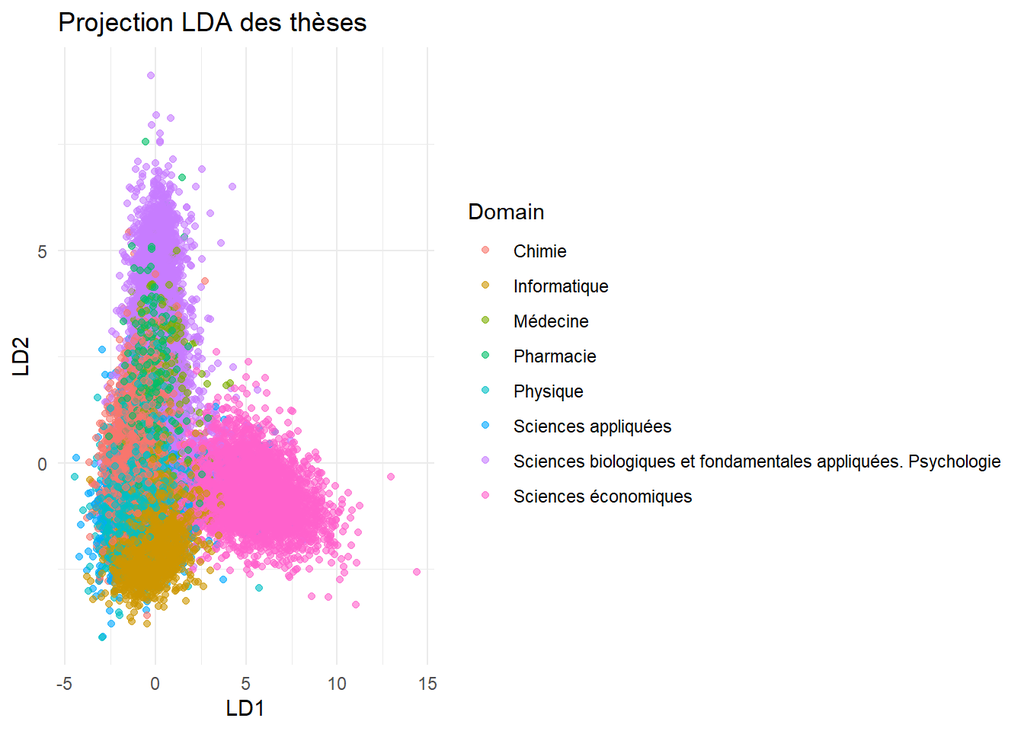

```r
lda_values <- as.data.frame(X_train_lda)
lda_values$Domain <- Y_train

p <- ggplot(lda_values, aes(x = LD1, y = LD2, color = Domain)) +
  geom_point(alpha = 0.6) +
  theme_minimal() +
  ggtitle("Projection LDA des thèses")

p
```

Chaque point représente une thèse analysée. Chaque couleur représente un domaine d’études.

**==> On observe que plusieurs groupes sont bien définis et représente une entité à part entière (Sciences économiques, Informatique, Sciences bologiques,…)**

==> On remarque également une superposition de plusieurs domaines ensemble (Pharmacie, Chimie, Physique, Médecine). Cela confirme notre théorie sur les liens intrinsèques entre ces différents sujets.

==> De manière générale, les matières scientifiques sont groupés entre elles tandis que les autres se distinguent de par leur vocabulaire/domaine plus identifiable.

### 5.2 Graphique 2

Ici, avec l’aide de l’IA, on propose de génèrer un histogramme qui représente les principaux mots discriminants de notre modèle. Pour ce faire, on décide de récupérer les points des mots dans chaque composante créée ainsi que les coefficients de la LDA. On effectue par la suite un produit matriciel et on récupère nos données dans une dataFrame. On obtient un tableau des poids de chaque mot. On visualise alors les 20 mots les plus discriminants sur LD1 :

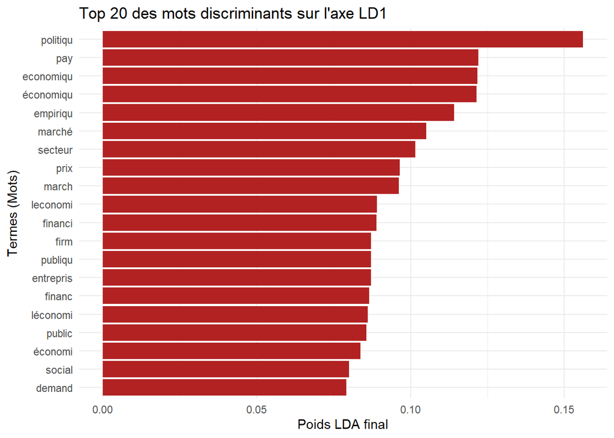

```r
# 1. Récupérer les rotations de la PCA (poids des mots dans chaque PC).
pca_rotations <- pca_model$rotation[, 1:n_comp]

# 2. Récupérer les coefficients de la LDA.
lda_scalings <- lda_model$scaling

# 3. Calculer l'influence directe des mots sur les axes LD (Produit matriciel).
word_influence <- pca_rotations %*% lda_scalings

# 4. Préparer les données pour le graphique
word_influence_df <- as.data.frame(word_influence)
word_influence_df$term <- rownames(word_influence_df)

# 5. Visualiser les 20 mots les plus discriminants pour LD1.
top_words_ld1 <- word_influence_df %>%
  arrange(desc(abs(LD1))) %>%
  head(20)

q <- ggplot(top_words_ld1, aes(x = reorder(term, LD1), y = LD1)) +
  geom_col(fill = "firebrick") +
  coord_flip() +
  theme_minimal() +
  labs(title = "Top 20 des mots discriminants sur l'axe LD1",
       x = "Termes (Mots)", y = "Poids LDA final")

q
```

**==> On remarque tout de suite que les mots plus discriminants sur cette axe sont tous liés aux sciences économiques (économie, politique, marché, firme,…). Ceci explique notamment la séparation immédiate du domaine sur le graphique précédent selon LD1.**

On peut réaliser la même chose sur un autre axe (LD2) :

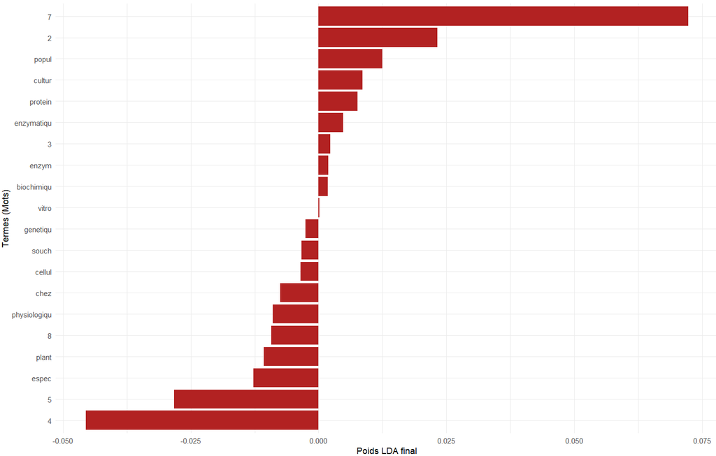

**==> On voit cette fois-ci que les termes les plus discriminants sont liés à la biologie cellulaire (proteine, enzyme, genetique,…). Certains chiffres sont apparemment des facteurs importants également, peut-être lié ou non au domaine.**

**==> On peut en déduire que notre LD1 contrôle les mots du domaine socio-économique tandis que LD2 ceux du domaine médical. Ceci expliquerait pourquoi le graphique a une telle répartition nette entre “Sciences économiques” et le reste, principalement dans la santé.**

### 5.3 Graphique 3

Enfin, une dernière représentation graphique serait une *HeatMap* pour visualiser la matrice de confusion des prédictions vs réalité. On extrait donc la matrice de confusion de notre modèle et on l’affiche :

[figure not shown]

```r
conf_matrix <- as.data.frame(confusion_matrix_lda$table)
r <- ggplot(data = conf_matrix, aes(x = Reference, y = Prediction, fill = Freq)) +
  geom_tile(color = "white") +
  scale_fill_gradient(low = "white", high = "steelblue") +
  geom_text(aes(label = Freq), vjust = 1) +
  theme_minimal() +
  labs(title = "Matrice de Confusion : Domaines Réels vs Prédictions",
       subtitle = "Analyse de la classification bayésienne",
       x = "Domaine Réel (Référence)",
       y = "Domaine Prédit",
       fill = "Nombre de thèses") +
  theme(axis.text.x = element_text(angle = 45, hjust = 1))

r
```

Version zoomée :

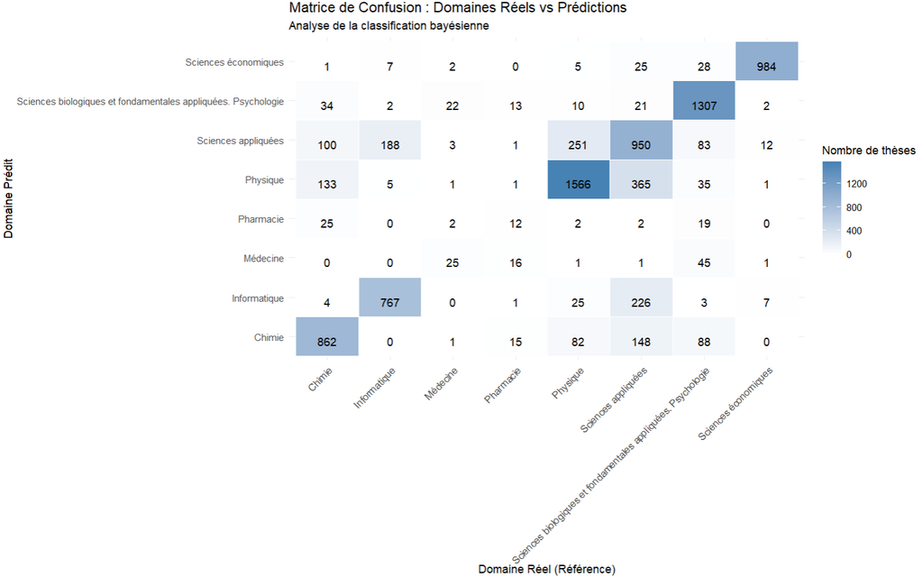

**==> On voit que sur la diagonale montante, les nombres sont plus importants et colorés, ce qui nous affirme que le modèle a globalement su prédire les bonnes classes pour les bons termes.**

**==> On peut cependant relever plusieurs classes qui se chevauchent, en particulier autour de “Physique”. Encore une fois, ceci s’explique par la polyvalence de ce domaine dans plusieurs autres, ce qui le rend généraliste et moins attrait à l’analyse discriminante.**

## 6 Conclusion

En conclusion, ce projet a permis de mettre en oeuvre une chaîne de traitement complète de classification, en s’appuyant sur des techniques de traitement du langage naturel et de classification bayésienne. Grâce à l’utilisation de l’Analyse Discriminate Linéaire, on a pu réduire la dmensionnalité tout en maximisant la séparabilité des classes, et ainsi trouver un modèle robuste et performant.  
Bien que cesdites performances soient satisfaisantes, des défis restent, notamment concernant certains déséquilibres de classes pour certains domaines d’études. Une possibilité future serait alors d’explorer des méthodes non linéaires et ou des modèles de langage profond, qui pourraient apporter plus de distinction entre les sujets de recherche très proches.  
Au final, ce projet souligne q’il est possible, grâce à une approche bayésienne, de pouvoir rechercher et caractériser la similarité sémantique entre plusieurs termes et ainsi, pouvoir les organiser selon leurs domaines de prédilection.